```python
import pandas as pd
import os
import numpy as np
from sklearn.linear_model import LinearRegression
import statsmodels.formula.api as sm
from statsmodels.tools.tools import add_constant
from sklearn.ensemble import RandomForestRegressor
from sklearn.cross_validation import cross_val_score
from sklearn.cross_validation import train_test_split
from sklearn.grid_search import GridSearchCV
from random import randint
import random
import seaborn as sb
import charts
```

# Executive Summary

What factors determine high school graduation rates? In this analysis, we build a random forest model using ~140 variables from census, school financials, weather, and food access data. Our results indicate that the most important factors determining high school graduation rates are economic security, household stability, and demographic variables. Importantly, we find that household stability, even when controlling for many other variables, is the most important factor next to socioeconomic status. We also find that weather plays an important role: colder areas tend to have lower graduation rates. Lastly, we find that spending on instruction (as opposed to other types of spending, such as on student support or administration) is the only type of spending that tends to improve graduation rates. However, our model predicts that our national graduation rate will not improve by increasing instructional spending more than its current level.

In terms of predictive power, our best random forest model has an out-of-bag score of 0.68, which is equivalent to an out-of-sample R2 score of 0.68.

As a result of our analysis, our recommendations are to focus more attention on creating a stable and nourishing household environment for students, finding ways for schools in colder areas to combat inclement weather, prioritizing improving quality of curriculum over increased instructional spending, and finding ways to release more precise graduation rate data without infringing on privacy rights.

Our analysis proceeds as follows: Part I outlines our theoretical foundations, hypotheses, and data sources. Part II deals with problems with the graduation rate data. Part III explores the relationship between the graduation rate data and our key variables of interest. Part IV builds and evaluates multiple predictive models. Part V ends with recommendations and conclusions.

# Part I: Theoretical foundations, hypotheses, and data sources

**What determines high school graduation rates?** Drawing from [ecological systems theory](https://www.wikiwand.com/en/Ecological_systems_theory), we focused on the *environments* that students interact with as the basis for their academic success. We then thought of specific factors within these environments that we thought might influence high school graduation rates.

The four major environments we looked at were: the household, school, neighborhood, and region. The following diagram helps to visualize this framework:

[figure not shown]

Now let's get into some of the details about each of these environments.

1) **Household**

Students spend more time at home then they do at school, which makes the home an important environment to dig into. We think that household structure and stability probably played important roles in a student's success.

*Hypothesis 1*: Students that live in more educated households will be more likely to graduate from high school since expectations of graduating high school are higher and parents probably exhibit better parenting patterns.

*Variables*:

- Percent of people over 25 years old that graduated high school
- Percent of people over 25 years old that graduated college

*Hypothesis 2*: Students that live in stabler households will be more likely to graduate from high school since they have to deal with fewer transitions and disruptions in their family lives.

*Variables*:

- Percent of households with married couple
- Percent of households with female only householders (no husband)
- Percent of households where the householder moved in during the past year
- Percent of people who had a different house 1 year ago

*Hypothesis 3*: Students that live in economically secure households will be more likely to graduate from high school because they have greater access to resources and less psychological strain.

*Variables*:

- Percent of people under the poverty line
- Median household income

*Data*: The data source and documentation for all of these variables can be found in the provided 2010 Census Data. These variables are at the tract level, which we weighted and merged with the graduation rates data.

2) **School**

Obviously, a student's school is a relevant environment to look at when trying to determine high school graduation rates. We focused our attention on how schools allocate financial resources across different areas, and how that allocation affects graduation rates.

*Hypothesis 4*: Schools that spend more money on instruction tend to have better graduation rates compared to schools that have higher support spending or adminstrative costs.

*Variables*:

- Total Instructional Spending, per pupil ($) - total spending dedicated to instruction
- Total Instructional Spending on Salaries and Wages, per pupil ($) - salaries and wages dedicated to instruction
- Total Instructional Spending on Benefits, per pupil ($) - benefits dedicated to instruction
- Total Support Spending, per pupil ($) - expenditure on on secondary services in a school, such as administration, maintenance, transportation, and social services.
- Total Support Spending on Pupil Support, per pupil ($) - expenditure on service such as social services and record keeping
- Total Support Spending on Instructional Staff Support, per pupil ($) - expenditure services such as curriculum development and trainings
- Total Support Spending on General Administration, per pupil ($) - expenditure on board of education and executive administration services
- Total Support Spending on School Administration, per pupil ($) - expenditure on office of principal services

*Data*: we used school expenditure data for the 2011-2012 school year from http://www.census.gov/govs/school/historical_data_2012.html. All of these variables are at the school district level.

For more precise defintions of the instruction and support spending variables, see the appendix of this report: http://www2.census.gov/govs/school/12f33pub.pdf

3) **Neighborhood**

There are many variables at the neighborhood level that we could look at, but note that many of them are captured at the household level. For example, the percent of people with college degrees can indicate how educated the average household is, but also captures the general attitude towards education in that district.

Instead, we focused on a more geographic variable in the neighborhood environment: food access.

*Hypothesis 5*: Students that live in districts with greater food access are healthier and perform better in school, leading to higher graduation rates.

*Data*: The data and documentation for determining low access districts can be found here: http://www.ers.usda.gov/data-products/food-access-research-atlas/download-the-data.aspx. The data is provided for the 2010 year at the tract level, which we aggregated up to the district level.

4) **Region**

Following the theme of increasing environment sizes, the next environment we considered is a student's region. The particular feature we focused on in this environment were weather patterns, which we operationalized in the data using temperature data.

*Hypothesis 6*: Schools in extreme temperature areas tend to have lower graduation rates compared to schools in more moderate climates because of higher absentee and school cancellation rates.

*Variables*:

- Average daily maximum temperature during 2011 (degrees Farenheit)
- Average daily minimum temperature during 2011 (degrees Farenheit)

*Data*: we used 2011 temperature data from http://www.ncdc.noaa.gov/temp-and-precip/climatological-rankings/, produced by the the National Centers for Environmental Information. The data is at the county level, which we merged onto the county and state codes of the highest overlapping tract for each district.

### Data Mapping

The image below shows how we combined the various datasets.

[figure not shown]

# Part II: Exploring the dependent variable: The graduation rate

## Major problems with the graduation rate data

Before we can explore the relationships between the data we collected and graduation rates, we need to understand and address any problems with our graduation rate data.

#### Problem 1 with the graduation rate data: Ranges were not cleaned properly

At first, we were going to use the graduation rates from the merged dataset that the organizers had provided us with because these graduation rates were supposedly cleaned. The original data had ranges and non-numeric characters in the dataset. To clean up the graduation rates, the organizers had removed all non-numeric characters and selected the median value for all ranges

However, we discovered an issue with how the graduation rates had been cleaned. We looked at the [documentation of the graduation rates dataset](https://inventory.data.gov/dataset/adjusted-cohort-graduation-rates-at-the-school-level-school-year-2011-12) and found that the some of the graduation rates had been masked because of privacy concerns. If the school had too few students, the graduation rate would either not be given, or it would be given as ranges of varying sizes depending on the size of the school. The different tiers of ranges are listed below:

**Ranges Used for Reporting the Graduation Rate for that Group**

**<5 students in cohort**: "PS" (i.e. the graduation rate is not given)

**6-15 students in cohort**: <50%, ≥50%

**16-30 students in cohort**: ≤20%, 21-39%, 40-59%, 60-79% ≥80%

**31-60 students in cohort**: ≤10%, 11-19%, 20-29%, 30-39%, 40-49%, 50-59%, 60-69%, 70-79%, 80-89%, ≥90%

**61-200 students in cohort**: ≤5%, 6-9%, 10-14%, 15-19%, 20-24%, 24-29%, 30-34%, 35-39%, 40-44%, 45-49%, 50-54%, 55-59%, 60-64%, 65-69%, 70-74%, 75-79%, 80-84%, 85-89%, 90-94%, ≥95%

**More than 200 students in cohort**: ≤1%, 2%, 3%, . . . , 98%, ≥99%

(Note: the documentation says that the last tier of the ranges (>200 students) is actually for >300 students. But if we look at the data, it turns out that any district with >200 students has only a single number given for the graduation rate, and any district with 61-200 students has a 4- or 5-number range (ex. 11-19%))

Now, the organizers claimed that when there was a range, they calculated the median value. The issue is that not all of the ranges were given as explicit ranges. For example, 6-9% or 11-19% would be given as 6-9 or 11-19. The organizers calculated the medians of these ranges correctly. In this example, they would have returned 7.5 and 15, respectively, as the values.

But the database also had ranges such as less than 20% or greater than or equal to 50%, which were given as LT20 ("less than" 20) or GE50 ("greater than or equal to" 50). In these cases, the organizers merely removed the non-numeric characters and returned 20 and 50 as the graduation rates (respectively). If they had applied the same methodology to ranges consistently, they should have calculated the median of 0-20 and 50-100, which would have returned 10 and 75.

The issue is demonstrated in the tables below.

```python
# read in the merged and unmerged dataset
districts_merged = pd.read_csv("data_to_upload_to_ipnotebook/merged/graduation_with_census.csv")
districts_merged.shape

desired_cols = districts_merged.columns[0:27]
districts_merged = districts_merged[desired_cols]
districts_merged.rename(columns = {"ALL_RATE_1112": "clean_grad_rate"}, inplace = True)

districts_unmerged = pd.read_csv("data_to_upload_to_ipnotebook/unmerged/Graduation_Rates.csv")
districts_unmerged.columns
unmerged_only_grad_rate_and_leaid = districts_unmerged[["ALL_RATE_1112", "leaid11", "ALL_COHORT_1112"]]
merged_only_grad_rate_and_leaid = districts_merged[["clean_grad_rate", "leaid11"]]

compare_grad_rates = merged_only_grad_rate_and_leaid.merge(unmerged_only_grad_rate_and_leaid, on = "leaid11", how = "outer")
compare_grad_rates.rename(columns=dict(leaid11 = "LEA ID", ALL_COHORT_1112="Cohort Size", clean_grad_rate= "Cleaned Grad Rate", ALL_RATE_1112="Raw Grad Rate" ), inplace = True)

compare_grad_rates[((compare_grad_rates["Raw Grad Rate"] == "90-94") |
                  (compare_grad_rates["Raw Grad Rate"] == "80-89") |
                  (compare_grad_rates["Raw Grad Rate"] == "GE90") |
                  (compare_grad_rates["Raw Grad Rate"] == "LT50")) &
                  (pd.notnull(compare_grad_rates["Cleaned Grad Rate"]))][["LEA ID", "Cohort Size", "Cleaned Grad Rate", "Raw Grad Rate"]][0:50]

print "Table 1: Grad Rates for Schools with >200 Cohort Size (Organizer's Data)"
print compare_grad_rates[compare_grad_rates["Cohort Size"] > 200].iloc[0:3][["LEA ID", "Cohort Size", "Cleaned Grad Rate", "Raw Grad Rate"]]
print

print "Table 2: Grad Rates for Schools with 61-200 Cohort Size (Organizer's Data)"
print compare_grad_rates[(compare_grad_rates["Cohort Size"] <= 200) & (compare_grad_rates["Cohort Size"] > 60)].iloc[0:3][["LEA ID", "Cohort Size", "Cleaned Grad Rate", "Raw Grad Rate"]]
print

print "Table 3: Grad Rates for Schools with 31-60 Cohort Size (Organizer's Data)"
print compare_grad_rates[(compare_grad_rates["Cohort Size"] <= 60) & (compare_grad_rates["Cohort Size"] > 30)].iloc[0:3][["LEA ID", "Cohort Size", "Cleaned Grad Rate", "Raw Grad Rate"]]
print

print "Table 4: Grad Rates for Schools with 16-30 Cohort Size (Organizer's Data)"
print compare_grad_rates[(compare_grad_rates["Cohort Size"] <= 30) & (compare_grad_rates["Cohort Size"] > 15)][0:3][["LEA ID", "Cohort Size", "Cleaned Grad Rate", "Raw Grad Rate"]]
print

print "Table 5: Grad Rates for Schools with 6-15 Cohort Size (Organizer's Data)"
print compare_grad_rates[(compare_grad_rates["Cohort Size"] <= 15) & (compare_grad_rates["Cohort Size"] > 5)][0:3][["LEA ID", "Cohort Size", "Cleaned Grad Rate", "Raw Grad Rate"]]
print

print "Table 6: Grad Rates for Schools with 1-5 Cohort Size (Organizer's Data)"
print compare_grad_rates[(compare_grad_rates["Cohort Size"] <= 5)][0:3][["LEA ID", "Cohort Size", "Cleaned Grad Rate", "Raw Grad Rate"]]
```

```
Table 1: Grad Rates for Schools with >200 Cohort Size (Organizer's Data)
   LEA ID  Cohort Size  Cleaned Grad Rate Raw Grad Rate
0  100005          268                 83            83
1  100006          424                 79            79
2  100007         1042                 91            91

Table 2: Grad Rates for Schools with 61-200 Cohort Size (Organizer's Data)
   LEA ID  Cohort Size  Cleaned Grad Rate Raw Grad Rate
4  100011          117                 72         70-74
5  100012          155                 92         90-94
8  100060          109                 77         75-79

Table 3: Grad Rates for Schools with 31-60 Cohort Size (Organizer's Data)
     LEA ID  Cohort Size  Cleaned Grad Rate Raw Grad Rate
76   101980           49               74.5         70-79
81   102130           44               84.5         80-89
134  200004           31               34.5         30-39

Table 4: Grad Rates for Schools with 16-30 Cohort Size (Organizer's Data)
     LEA ID  Cohort Size  Cleaned Grad Rate Raw Grad Rate
135  200007           20               69.5         60-79
138  200030           16               69.5         60-79
140  200060           26               80.0          GE80

Table 5: Grad Rates for Schools with 6-15 Cohort Size (Organizer's Data)
     LEA ID  Cohort Size  Cleaned Grad Rate Raw Grad Rate
151  200300            9                 50          GE50
154  200450           15                 50          GE50
167  200680           11                NaN          LT50

Table 6: Grad Rates for Schools with 1-5 Cohort Size (Organizer's Data)
     LEA ID  Cohort Size  Cleaned Grad Rate Raw Grad Rate
136  200010            3                NaN            PS
152  200360            1                NaN            PS
166  200670            5                NaN            PS
```

In the above tables, we can see how the organizers handled the graduation rates. The "Raw Grad Rate" column indicates the original value in the dataset. The "Cleaned Grad Rate" shows how the organizers cleaned the raw graduation rate.

For ranges indicated with hyphens (such in Tables 2, 3, and 4), the organizers took the median of the two numbers. But some of the ranges are indicated with inequality operators, such as GE80 (greater than or equal to 80) or LT50 (less than 50) (see tables 4 and 5). The median value should have been calculated for these ranges as well, but they were not. Instead, the non-numeric characters were removed without the median calculation.

After realizing this, we decided to clean up the grad rate ourselves. The following charts show how our cleaned graduation rate compares.

```python
grad_rates = pd.read_csv("final_district_dataset.csv")
compare_grad_rates = grad_rates[["leaid11", "ALL_RATE_1112", "clean_grad_rate", "ALL_COHORT_1112"]].copy()

compare_grad_rates.rename(columns = {"leaid11": "LEA ID", "ALL_COHORT_1112": "Cohort Size",
                                    "ALL_RATE_1112": "Raw Grad Rate",
                                    "clean_grad_rate": "Cleaned Grad Rate"}, inplace = True)

print "Table 7: Grad Rates for Schools with >200 Cohort Size (Our Data)"
print compare_grad_rates[compare_grad_rates["Cohort Size"] > 200].iloc[0:3][["LEA ID", "Cohort Size", "Cleaned Grad Rate", "Raw Grad Rate"]]
print

print "Table 8: Grad Rates for Schools with 61-200 Cohort Size (Our Data)"
print compare_grad_rates[(compare_grad_rates["Cohort Size"] <= 200) & (compare_grad_rates["Cohort Size"] > 60)].iloc[0:3][["LEA ID", "Cohort Size", "Cleaned Grad Rate", "Raw Grad Rate"]]
print

print "Table 9: Grad Rates for Schools with 31-60 Cohort Size (Our Data)"
print compare_grad_rates[(compare_grad_rates["Cohort Size"] <= 60) & (compare_grad_rates["Cohort Size"] > 30)].iloc[0:3][["LEA ID", "Cohort Size", "Cleaned Grad Rate", "Raw Grad Rate"]]
print

print "Table 10: Grad Rates for Schools with 16-30 Cohort Size (Our Data)"
print compare_grad_rates[(compare_grad_rates["Cohort Size"] <= 30) & (compare_grad_rates["Cohort Size"] > 15)][0:3][["LEA ID", "Cohort Size", "Cleaned Grad Rate", "Raw Grad Rate"]]
print

print "Table 11: Grad Rates for Schools with 6-15 Cohort Size (Our Data)"
print compare_grad_rates[(compare_grad_rates["Cohort Size"] <= 15) & (compare_grad_rates["Cohort Size"] > 5)][0:3][["LEA ID", "Cohort Size", "Cleaned Grad Rate", "Raw Grad Rate"]]
print
```

```
Table 7: Grad Rates for Schools with >200 Cohort Size (Our Data)
   LEA ID  Cohort Size  Cleaned Grad Rate Raw Grad Rate
0  100005          268                 83            83
1  100006          424                 79            79
2  100007         1042                 91            91

Table 8: Grad Rates for Schools with 61-200 Cohort Size (Our Data)
   LEA ID  Cohort Size  Cleaned Grad Rate Raw Grad Rate
4  100011          117                 72         70-74
5  100012          155                 92         90-94
8  100060          109                 77         75-79

Table 9: Grad Rates for Schools with 31-60 Cohort Size (Our Data)
     LEA ID  Cohort Size  Cleaned Grad Rate Raw Grad Rate
76   101980           49               74.5         70-79
81   102130           44               84.5         80-89
134  200004           31               34.5         30-39

Table 10: Grad Rates for Schools with 16-30 Cohort Size (Our Data)
     LEA ID  Cohort Size  Cleaned Grad Rate Raw Grad Rate
135  200007           20               69.5         60-79
137  200030           16               69.5         60-79
139  200060           26               90.0          GE80

Table 11: Grad Rates for Schools with 6-15 Cohort Size (Our Data)
     LEA ID  Cohort Size  Cleaned Grad Rate Raw Grad Rate
150  200300            9                 75          GE50
152  200450           15                 75          GE50
164  200680           11                 25          LT50
```

The above charts show how we cleaned the data. For ranges indicated by hyphens (such as tables 2, 3, and 4), we calculated the median values. Similarly, we also found the median value for ranges indicated by inequality operators We think this is a better representation of the graduation rates.

Note that we don't have a table for schools with cohort sizes of 1-5 since graduation rates were not provided for these schools.

#### Problem 2 with the graduation rate data: Low Variance

The second problem with the graduation rate data is that our variance is very low. The following code looks at the summary statistics of the dependent variable.

```python
grad_rates.clean_grad_rate.describe()
```

```
count    9802.000000
mean       85.571261
std        10.357597
min         2.500000
25%        80.250000
50%        88.000000
75%        92.000000
max        99.500000
Name: clean_grad_rate, dtype: float64
```

These statistics show that the 1st quartile of the graduation rates is 80%. This means that 75% of the grad rates are between 80% and 100%, indicating low variance in the dependent variable. In other words, the dependent variable is concentrated in a narrow range of values

So this means that even a difference of 1 percentage point will make a big difference. But since many of our dependent variables are given in ranges, we lose precision in the dependent variable, making our predictive models weaker.

But note that for schools with cohorts greater than 200 students, the graduation rate is given as a single, precise number, not as a range. If we we could limit our data to just schools with over 200 students in their cohort, we would get much more precision and be able to measure effects of our key variables with greater accuracy.

In order to see if we can legitimately limit our data to schools with cohorts >200 students, we need to look at three things:

1. What portion of schools do schools with >200 cohort size represent?
2. What portion of total students are in schools with >200 students in their cohort?
3. Are the graduation rates for schools with >200 cohort size systematically different from the typical graduation rates across schools?

We examine each of these questions in more detail.

##### What portion of schools have over 200 students in their cohort?

The following code show a graph which breaks down the distribution of schools by cohort sizes. The cohort size buckets that we use are the tiers that determine how precise the graduation rate is (>200, 61-200, 31-60, 16-30, and 6-15).

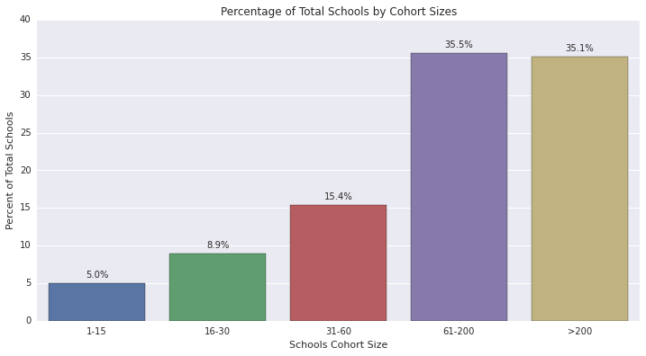

```python
import matplotlib.pyplot as plt

total_number_of_school_districts = grad_rates.shape[0]
percent_schools_greater_than_200_cohort = grad_rates[grad_rates.ALL_COHORT_1112 > 200].shape[0] * 100.0 / total_number_of_school_districts
percent_schools_61_to_200_cohort = grad_rates[(grad_rates.ALL_COHORT_1112 <= 200) &  (grad_rates.ALL_COHORT_1112 > 60)].shape[0] * 100.0 / total_number_of_school_districts
percent_schools_31_to_60_cohort = grad_rates[(grad_rates.ALL_COHORT_1112 <= 60) &  (grad_rates.ALL_COHORT_1112 > 30)].shape[0] * 100.0 / total_number_of_school_districts
percent_schools_16_to_30_cohort = grad_rates[(grad_rates.ALL_COHORT_1112 <= 30) &  (grad_rates.ALL_COHORT_1112 > 15)].shape[0] * 100.0 / total_number_of_school_districts
percent_schools_less_than_16_cohort = grad_rates[grad_rates.ALL_COHORT_1112 <= 15].shape[0] * 100.0 / total_number_of_school_districts

variable_names = ["1-15",
                  "16-30",
                  "31-60",
                  "61-200",
                  ">200"]

variable_values = [percent_schools_less_than_16_cohort, percent_schools_16_to_30_cohort,
                   percent_schools_31_to_60_cohort, percent_schools_61_to_200_cohort,
                   percent_schools_greater_than_200_cohort]


f, ax = plt.subplots(figsize=(12, 6))
sb.barplot(x = variable_names , y = variable_values)

ax.set(ylabel="Percent of Total Schools",
       xlabel="Schools Cohort Size",
       title="Percentage of Total Schools by Cohort Sizes")

rects = ax.patches
labels = ["{}%".format(round(value, 1)) for value in variable_values]

for rect, label in zip(rects, labels):
    height = rect.get_height()
    x = rect.get_x() + rect.get_width()/2
    ax.annotate(label, xy = (rect.get_x(), rect.get_y()), xytext = (x, height + .5), ha = "center", va="bottom")
```

As we can see, schools with >200 cohort sizes represent 35% of all schools, second only to schools with cohort size ranging between 61-200, which is slightly higher. It's not a lot of schools, but it's not a little either.

##### How many students (as a proportion of the total number of students) are in schools with >200 students in their cohort?

Next, we look at the distribution of *students* across schools of different cohort sizes. Basically, we want to see how many students as a proportion of total students are in schoools with >200 cohort size, 61-200 cohort size, etc. The following graph shows this breakdown.

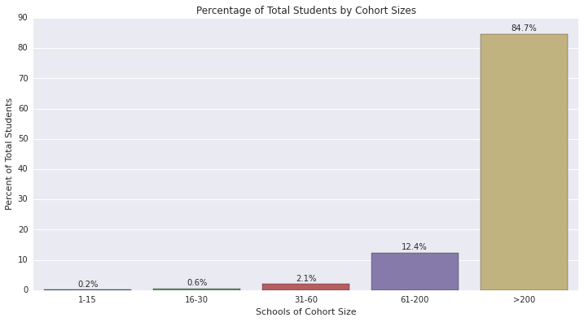

```python
import matplotlib.pyplot as plt

total_number_of_students = grad_rates.ALL_COHORT_1112.sum()
percent_of_students_in_schools_greater_than_200_cohort = grad_rates[grad_rates.ALL_COHORT_1112 > 200].ALL_COHORT_1112.sum() * 100.0 / total_number_of_students
percent_of_students_in_schools_with_61_to_200_cohort = grad_rates[(grad_rates.ALL_COHORT_1112 <= 200) &  (grad_rates.ALL_COHORT_1112 > 60)].ALL_COHORT_1112.sum() * 100.0 / total_number_of_students
percent_of_students_in_schools_with_31_to_60_cohort = grad_rates[(grad_rates.ALL_COHORT_1112 <= 60) &  (grad_rates.ALL_COHORT_1112 > 30)].ALL_COHORT_1112.sum() * 100.0 / total_number_of_students
percent_of_students_in_schools_with_16_to_30_cohort = grad_rates[(grad_rates.ALL_COHORT_1112 <= 30) &  (grad_rates.ALL_COHORT_1112 > 15)].ALL_COHORT_1112.sum() * 100.0 / total_number_of_students
percent_of_students_in_schools_less_than_16_cohort = grad_rates[grad_rates.ALL_COHORT_1112 <= 15].ALL_COHORT_1112.sum() * 100.0 / total_number_of_students

variable_names = ["1-15",
                  "16-30",
                  "31-60",
                  "61-200",
                  ">200"]

variable_values = [percent_of_students_in_schools_less_than_16_cohort, percent_of_students_in_schools_with_16_to_30_cohort,
                   percent_of_students_in_schools_with_31_to_60_cohort, percent_of_students_in_schools_with_61_to_200_cohort,
                   percent_of_students_in_schools_greater_than_200_cohort]


f, ax = plt.subplots(figsize=(12, 6))
sb.barplot(x = variable_names , y = variable_values)

ax.set(ylabel="Percent of Total Students",
       xlabel="Schools of Cohort Size",
       title = "Percentage of Total Students by Cohort Sizes")

rects = ax.patches
labels = ["{}%".format(round(value, 1)) for value in variable_values]

for rect, label in zip(rects, labels):
    height = rect.get_height()
    x = rect.get_x() + rect.get_width()/2
    ax.annotate(label, xy = (rect.get_x(), rect.get_y()), xytext = (x, height + 1), ha = "center")
```

This graph is telling us good news. It's saying that 85% of all students are in schools with >200 cohort size. This strengthens our case to use only data for schools with >200 students in their cohort. Now, for the last question...

##### Are graduation rates systematically different for schools with cohorts >200?

Basically, we want to know if there is something about larger schools that makes them different from other schools. If so, we would introduce bias into our analysis if we limited our data to just schools with >200 students in their cohort.

To check this, we compared baseline statistics for graduation rates for a) all schools, b) schools with less than or equal to 200 students in the cohort, and c) schools with greater than 200 students in their cohort.

```python
print "Table 12: Summary statistics for graduation rates for all schools"
print grad_rates.clean_grad_rate.describe()

print

print "Table 13: Summary statistics for graduation rates for schools with <=200 cohort size"
print grad_rates.clean_grad_rate[grad_rates.ALL_COHORT_1112 <= 200].describe()

print

print "Table 14: Summary statistics for graduation rates for schools with >200 cohort size"
grad_rates.clean_grad_rate[grad_rates.ALL_COHORT_1112 > 200].describe()
```

```
Table 12: Summary statistics for graduation rates for all schools
count    9802.000000
mean       85.571261
std        10.357597
min         2.500000
25%        80.250000
50%        88.000000
75%        92.000000
max        99.500000
Name: clean_grad_rate, dtype: float64

Table 13: Summary statistics for graduation rates for schools with <=200 cohort size
count    6362.000000
mean       86.206303
std        10.310099
min         2.500000
25%        82.000000
50%        90.000000
75%        92.000000
max        97.500000
Name: clean_grad_rate, dtype: float64

Table 14: Summary statistics for graduation rates for schools with >200 cohort size
```

```
count    3440.000000
mean       84.396802
std        10.344128
min        18.000000
25%        79.000000
50%        86.000000
75%        92.000000
max        99.500000
Name: clean_grad_rate, dtype: float64
```

As we can see, the graduation rates for all schools and graduation rates for schools with cohort size <=200 are very similar to the graduation rates for schools with >200 cohort sizes. The means and standard deviations are about the same. Again, this strengthens the case for limiting our data to schools with >200 cohort sizes.

##### So what should we do?

On the other hand, schools with >200 cohort sizes represent 35% of all schools and 84% of all students. They don't represent as much data as the >60 subset, but all the graduation rates are precise, single numbers, which improves our precision and accuracy of estimates.

So, there is a trade-off between how much data we use in our analysis, and how precise that data is. If we use schools >200, we have less data but more precise data (and thus more accurate estimates). If we use schools >60, we have more data, but less precise data.

Since >200 cohort schools are not systematically different from other schools, **we chose to build a model only for schools with cohorts >200**. However, to make sure that this model is generalizable to all schools, we compared it to a model built on >60 cohort schools to make sure they seem generally similar. As we will see, we found that they are generally the same.

# Part III: Exploring the Relationships between independent and dependent variables

Note that we also offer static visualizations below this chart that also show a line of best fit. Feel free to skip ahead to those graphs.

```python
import charts
grad_rates = pd.read_csv("final_district_dataset.csv")
grad_rates_greater_than_200_cohort = grad_rates[grad_rates.ALL_COHORT_1112 > 200]
data = zip(grad_rates.pct_married_HH, grad_rates_greater_than_200_cohort.clean_grad_rate)

series = [{
        "name": "Married Households (% of total HHs)",
        "data": zip(grad_rates_greater_than_200_cohort.pct_married_HH, grad_rates_greater_than_200_cohort.clean_grad_rate)
    }, {
        "name": "Female Householder Only (no husband) Households (% of total HHs)",
        "data": zip(grad_rates_greater_than_200_cohort.pct_female_only_HH, grad_rates_greater_than_200_cohort.clean_grad_rate)
    }, {
        "name": "Renter Occupied Households  (% of total households)",
        "data": zip(grad_rates_greater_than_200_cohort.perc_ECD_in_cohort, grad_rates_greater_than_200_cohort.clean_grad_rate)
    },{
        "name": "Households where Householder Moved in During Past Year  (% of total households)",
        "data": zip(grad_rates_greater_than_200_cohort.pct_HHs_where_householder_moved_in_2010, grad_rates_greater_than_200_cohort.clean_grad_rate)
    }, {
        "name": "People who had a different household 1 year ago  (% of people >1 year old)",
        "data": zip(grad_rates_greater_than_200_cohort.pct_people_with_different_HH_1yr_ago, grad_rates_greater_than_200_cohort.clean_grad_rate)
    }, {
        "name": "Economically Disadvantaged Students in graduating cohort  (% of cohort)",
        "data": zip(grad_rates_greater_than_200_cohort.perc_ECD_in_cohort, grad_rates_greater_than_200_cohort.clean_grad_rate)
    }, {
        "name": "People Below Poverty level  (% of total people in district)",
        "data": zip(grad_rates_greater_than_200_cohort.pct_people_below_poverty, grad_rates_greater_than_200_cohort.clean_grad_rate)
    }, {
        "name": "Weighted Median Neighborhood Income ($)",
        "data": zip(grad_rates_greater_than_200_cohort.weighted_Med_HHD_Inc_ACS_08_12, grad_rates_greater_than_200_cohort.clean_grad_rate)
    }, {
        "name": "Low Food Access (% of total overlapping tracts that have low food access))",
        "data": zip(grad_rates_greater_than_200_cohort.LAhalfand10, grad_rates_greater_than_200_cohort.clean_grad_rate)
    }, {
        "name": "Average Daily Maximum Temperature (Farenheit)",
        "data": zip(grad_rates_greater_than_200_cohort.avg_of_daily_max, grad_rates_greater_than_200_cohort.clean_grad_rate)
    }, {
        "name": "Average Daily Minimum Temperature (Farenheit)",
        "data": zip(grad_rates_greater_than_200_cohort.avg_of_daily_min, grad_rates_greater_than_200_cohort.clean_grad_rate)
    }, {
        "name": "Instruction Spending on Salaries and Wages, Per Pupil ($)",
        "data": zip(grad_rates_greater_than_200_cohort.instruction_salaries_and_wages_per_pupil, grad_rates_greater_than_200_cohort.clean_grad_rate)
    }, {
        "name": "Instruction Spending on Benefits, Per Pupil ($)",
        "data": zip(grad_rates_greater_than_200_cohort.instruction_benefits_per_pupil, grad_rates_greater_than_200_cohort.clean_grad_rate)
    }, {
        "name": "Support Spending on Pupil Support, Per Pupil ($)",
        "data": zip(grad_rates_greater_than_200_cohort.support_pupil_support_per_pupil, grad_rates_greater_than_200_cohort.clean_grad_rate)
    }, {
        "name": "Support Spending on Instructional Staff Support, Per Pupil ($)",
        "data": zip(grad_rates_greater_than_200_cohort.support_instructional_staff_per_pupil, grad_rates_greater_than_200_cohort.clean_grad_rate)
    }, {
        "name": "Support Spending on General Administration, Per Pupil ($)",
        "data": zip(grad_rates_greater_than_200_cohort.support_general_admin_per_pupil, grad_rates_greater_than_200_cohort.clean_grad_rate)
    }, {
        "name": "Support Spending on School Administration, Per Pupil ($)",
        "data": zip(grad_rates_greater_than_200_cohort.support_school_admin_per_pupil, grad_rates_greater_than_200_cohort.clean_grad_rate)
    }, {
        "name": "Support Spending on School Administration, Per Pupil ($)",
        "data": zip(grad_rates_greater_than_200_cohort.support_school_admin_per_pupil, grad_rates_greater_than_200_cohort.clean_grad_rate)
    }
         ]


options = dict(height=600,
               title=dict(text='Graduation Rates vs. Key Variables'),
               yaxis=dict(max = 100, min = 0, title=dict(text = "Graduation Rate")),
               chart=dict(zoomType='xy'))

charts.plot(series, options=options, save='temp.svg',
            show='inline', type = "scatter",
            display = "Married Households (% of total HHs)")
```

### Exploratory analysis of household variables

The next section isn't interactive, but allows us to look at general trends in our key variables of interest. Here are the high level insights for our variables:

**1) Stability variables**

The household stability variables all seem to follow the hypothesized relationships.

**2) Economic security variables**

The economic security variables all seem to follow the hypothesized relationships. Interestingly, it seems that there is a logarithmic relationship between median income and graduation rates. That is, there are diminishing returns to how much income affects graduation rates.

**3) Education variables**

Education variables also seem to follow the hypothesized relationships.

The graphs below show the actual correlations.

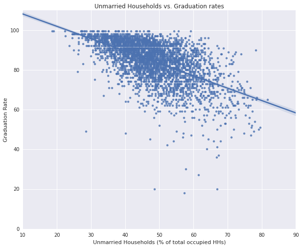

```python
import matplotlib as mpl

married_HH_plot = sb.regplot(x="pct_not_married_HH", y="clean_grad_rate",
           data=grad_rates_greater_than_200_cohort)

married_HH_plot.set(ylabel="Graduation Rate", xlabel="Unmarried Households (% of total occupied HHs)",
                    title = "Unmarried Households vs. Graduation rates",
                    ylim = (0, 110), xlim = (10, 90))

mpl.rc("figure", figsize=(10, 8))
```

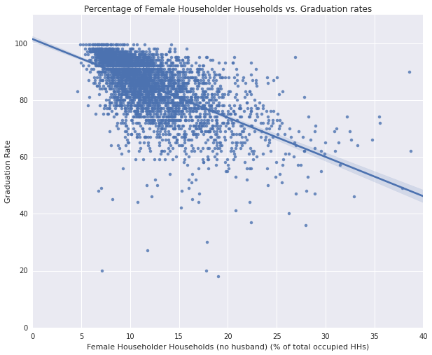

```python
married_HH_plot = sb.regplot(x="pct_female_only_HH", y="clean_grad_rate",
           data=grad_rates_greater_than_200_cohort)

married_HH_plot.set(ylabel="Graduation Rate", xlabel="Female Householder Households (no husband) (% of total occupied HHs)",
                    title = "Percentage of Female Householder Households vs. Graduation rates",
                    ylim = (0, 110), xlim = (0, 40))

mpl.rc("figure", figsize=(10, 8))
```

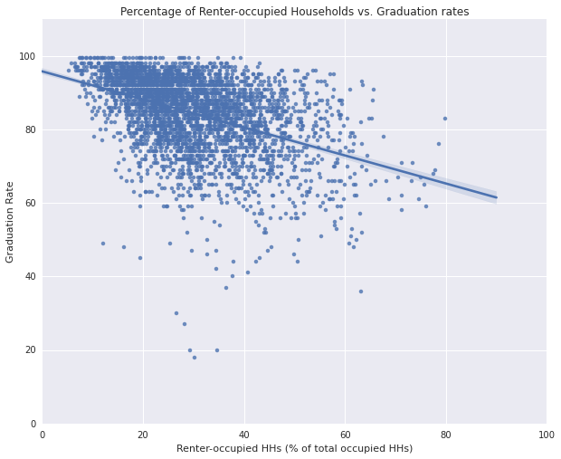

```python
plot = sb.regplot(x="pct_renter_occupied", y="clean_grad_rate",
           data=grad_rates_greater_than_200_cohort)

plot.set(ylabel="Graduation Rate", xlabel="Renter-occupied HHs (% of total occupied HHs)",
                            title = "Percentage of Renter-occupied Households vs. Graduation rates",
                            ylim = (0,110), xlim = (0, 100))

mpl.rc("figure", figsize=(10, 8))
```

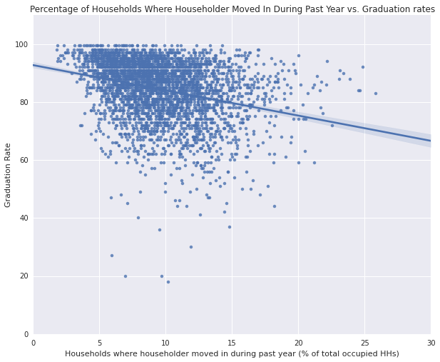

```python
plot = sb.regplot(x="pct_HHs_where_householder_moved_in_2010", y="clean_grad_rate",
           data=grad_rates_greater_than_200_cohort)

plot.set(ylabel="Graduation Rate", xlabel="Households where householder moved in during past year (% of total occupied HHs)",
                            title = "Percentage of Households Where Householder Moved In During Past Year vs. Graduation rates",
                            ylim = (0,110), xlim = (0, 30))

mpl.rc("figure", figsize=(10, 8))
```

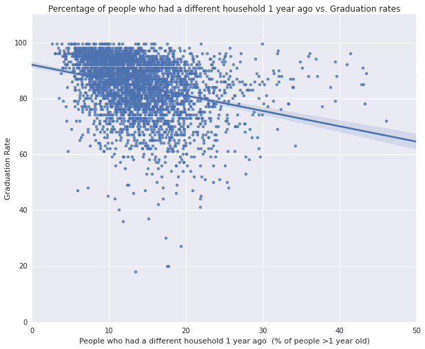

```python
plot = sb.regplot(x="pct_people_with_different_HH_1yr_ago", y="clean_grad_rate",
           data=grad_rates_greater_than_200_cohort)

plot.set(ylabel="Graduation Rate", xlabel="People who had a different household 1 year ago  (% of people >1 year old)",
                            title = "Percentage of people who had a different household 1 year ago vs. Graduation rates",
                            ylim = (0,110), xlim = (0, 50))

mpl.rc("figure", figsize=(10, 8))
```

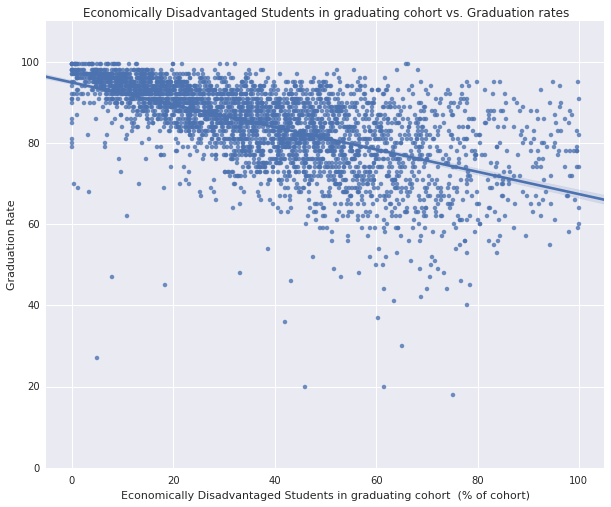

```python
plot = sb.regplot(x="perc_ECD_in_cohort", y="clean_grad_rate",
           data=grad_rates_greater_than_200_cohort)

plot.set(ylabel="Graduation Rate", xlabel="Economically Disadvantaged Students in graduating cohort  (% of cohort)",
                            title = "Economically Disadvantaged Students in graduating cohort vs. Graduation rates",
                            ylim = (0,110), xlim = (-5, 105))

mpl.rc("figure", figsize=(10, 8))
```

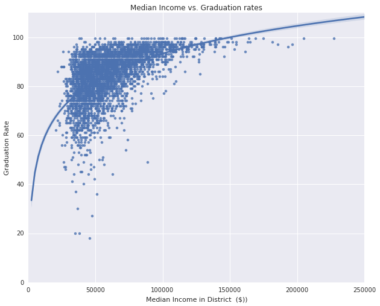

```python
plot = sb.regplot(x="weighted_Med_HHD_Inc_ACS_08_12", y="clean_grad_rate",
           data=grad_rates_greater_than_200_cohort, logx = True)

plot.set(ylabel="Graduation Rate", xlabel="Median Income in District  ($))",
                            title = "Median Income vs. Graduation rates",
                            ylim = (0,110))

mpl.rc("figure", figsize=(10, 8))
```

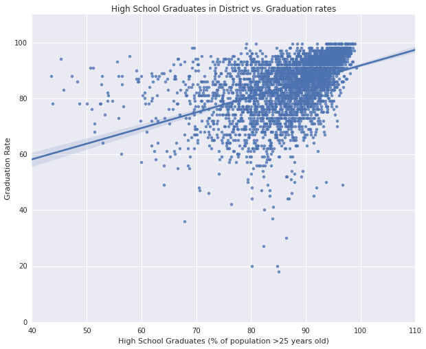

```python
plot = sb.regplot(x="pct_HS_grad", y="clean_grad_rate",
           data=grad_rates_greater_than_200_cohort)

plot.set(ylabel="Graduation Rate", xlabel="High School Graduates (% of population >25 years old)",
                            title = "High School Graduates in District vs. Graduation rates",
                            ylim = (0,110))

mpl.rc("figure", figsize=(10, 8))
```

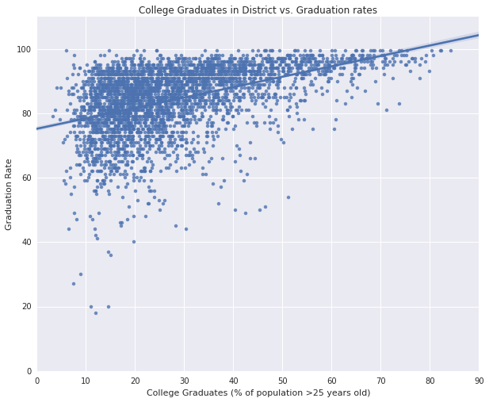

```python
plot = sb.regplot(x="pct_college_grad", y="clean_grad_rate",
           data=grad_rates_greater_than_200_cohort)

plot.set(ylabel="Graduation Rate", xlabel="College Graduates (% of population >25 years old)",
                            title = "College Graduates in District vs. Graduation rates",
                            ylim = (0,110), xlim = (0, 90))

mpl.rc("figure", figsize=(10, 8))
```

### Exploratory analysis of low food access

Interestingly, it does not seem that low food access is correlated with high school graduation rates. If anything, there seems to be a weakly positive correlation -- that is, as there are more low food access tracts, graduation rates improve. This might be because students in low food access tracts might get more nutritional support in schools.

The graph below shows the actual correlation.

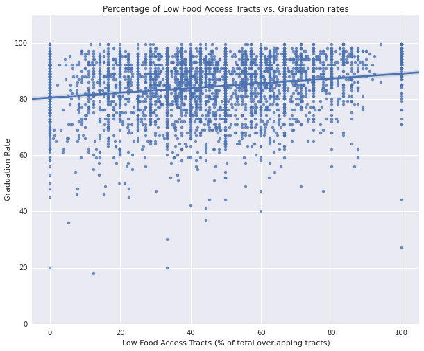

```python
low_food_access_HH_plot = sb.regplot(x="LA1and10", y="clean_grad_rate",
           data=grad_rates_greater_than_200_cohort)

low_food_access_HH_plot.set(ylabel="Graduation Rate", xlabel="Low Food Access Tracts (% of total overlapping tracts)",
                            title = "Percentage of Low Food Access Tracts vs. Graduation rates",
                            ylim = (0,110), xlim = (-5, 105))

mpl.rc("figure", figsize=(10, 5))
```

### Exploratory analysis of weather variables

There does not seem to be a very strong linear relationship between weather and high school graduation rates. However, there does seem to be a nonlinear relationship in the data. This makes sense because we would expect districts that are not too hot and not too cold to have better graduation rates. As we will see, our predictive model will pick up this nonlinear relationship and weather variables will be one of our most important features.

The graphs below show the actual correlations.

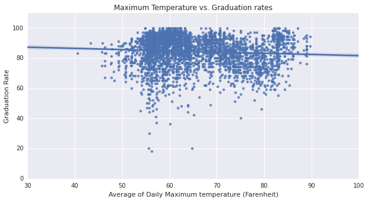

```python
plot = sb.regplot(x="avg_of_daily_max", y="clean_grad_rate",
           data=grad_rates_greater_than_200_cohort)

plot.set(ylabel="Graduation Rate", xlabel="Average of Daily Maximum temperature (Farenheit)",
                            title = "Maximum Temperature vs. Graduation rates",
                            ylim = (0,110))

mpl.rc("figure", figsize=(10, 8))
```

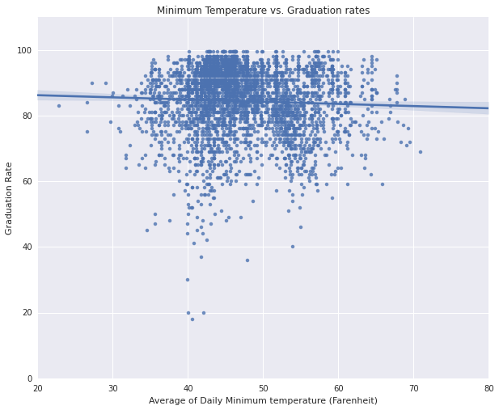

```python
plot = sb.regplot(x="avg_of_daily_min", y="clean_grad_rate",
           data=grad_rates_greater_than_200_cohort)

plot.set(ylabel="Graduation Rate", xlabel="Average of Daily Minimum temperature (Farenheit)",
                            title = "Minimum Temperature vs. Graduation rates",
                            ylim = (0,110))

mpl.rc("figure", figsize=(10, 8))
```

### Exploratory analysis of spending variables

The relationships between spending variables and graduation rates vary depending on which spending variables we look at. Here are high level insights

**Variables with positive correlation**: a) Instructional spending on wages and salaries and b) total instructional spending.

**Variables with negative correlation**: a) Support spending on instructional staff support.

**Variables with seemingly no correlation**: a) Total support spending, b) support spending on student support, c) support spending on general administration, and d) support spending on school administration

The graphs below show the actual correlations.

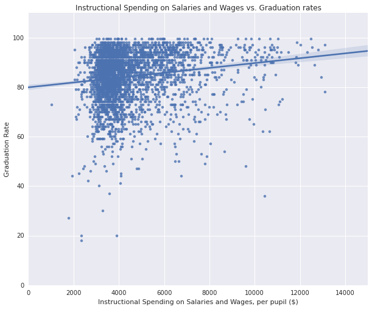

```python
plot = sb.regplot(x="instruction_salaries_and_wages_per_pupil", y="clean_grad_rate",
           data=grad_rates_greater_than_200_cohort)

plot.set(ylabel="Graduation Rate", xlabel="Instructional Spending on Salaries and Wages, per pupil ($)",
                            title = "Instructional Spending on Salaries and Wages vs. Graduation rates",
                            ylim = (0,110), xlim = (0, 15000))

mpl.rc("figure", figsize=(10, 8))
```

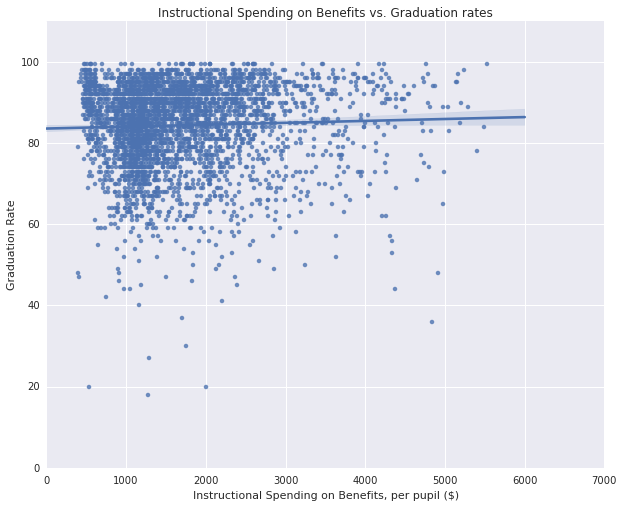

```python
plot = sb.regplot(x="instruction_benefits_per_pupil", y="clean_grad_rate",
           data=grad_rates_greater_than_200_cohort)

plot.set(ylabel="Graduation Rate", xlabel="Instructional Spending on Benefits, per pupil ($)",
                            title = "Instructional Spending on Benefits vs. Graduation rates",
                            ylim = (0,110), xlim = (0, 7000))

mpl.rc("figure", figsize=(10, 8))
```

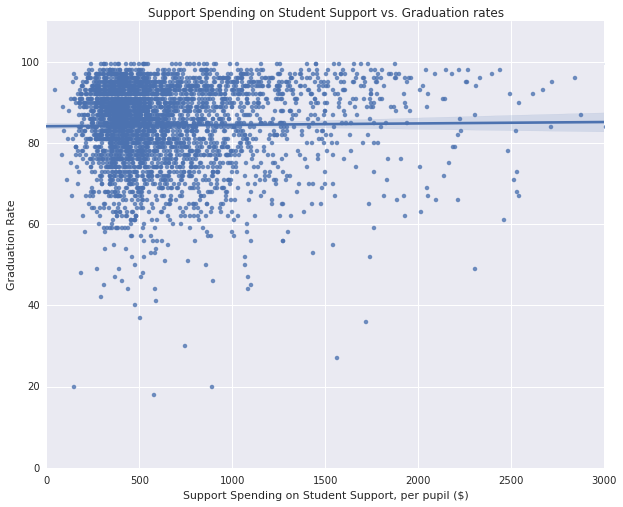

```python
plot = sb.regplot(x="support_pupil_support_per_pupil", y="clean_grad_rate",
           data=grad_rates_greater_than_200_cohort)

plot.set(ylabel="Graduation Rate", xlabel="Support Spending on Student Support, per pupil ($)",
                            title = "Support Spending on Student Support vs. Graduation rates",
                            ylim = (0,110), xlim = (0, 3000))

mpl.rc("figure", figsize=(10, 8))
```

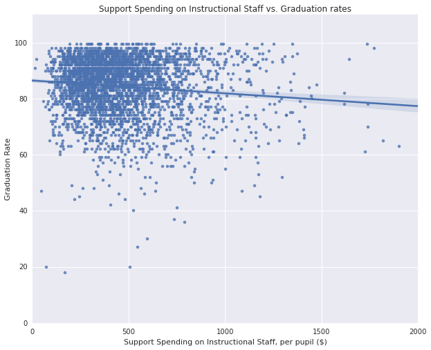

```python
plot = sb.regplot(x="support_instructional_staff_per_pupil", y="clean_grad_rate",
           data=grad_rates_greater_than_200_cohort)

plot.set(ylabel="Graduation Rate", xlabel="Support Spending on Instructional Staff, per pupil ($)",
                            title = "Support Spending on Instructional Staff vs. Graduation rates",
                            ylim = (0,110), xlim = (0, 2000))

mpl.rc("figure", figsize=(10, 8))
```

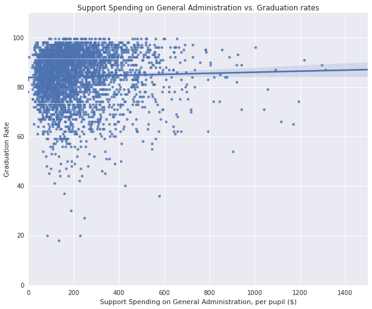

```python
plot = sb.regplot(x="support_general_admin_per_pupil", y="clean_grad_rate",
           data=grad_rates_greater_than_200_cohort)

plot.set(ylabel="Graduation Rate", xlabel="Support Spending on General Administration, per pupil ($)",
                            title = "Support Spending on General Administration vs. Graduation rates",
                            ylim = (0,110), xlim = (0, 1500))

mpl.rc("figure", figsize=(10, 8))
```

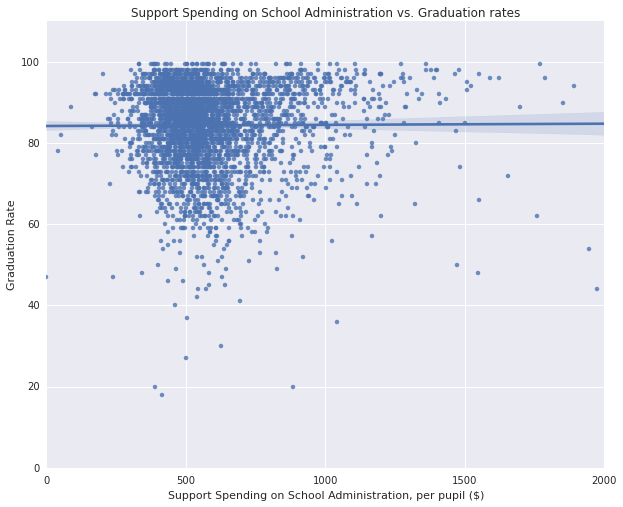

```python
plot = sb.regplot(x="support_school_admin_per_pupil", y="clean_grad_rate",
           data=grad_rates_greater_than_200_cohort)

plot.set(ylabel="Graduation Rate", xlabel="Support Spending on School Administration, per pupil ($)",
                            title = "Support Spending on School Administration vs. Graduation rates",
                            ylim = (0,110), xlim = (0, 2000))

mpl.rc("figure", figsize=(10, 8))
```

# Part IV. The Predictive Model

We have provided a theoretical foundation, cleaned up our dependent variable, and explored relationships between our variables of interest and graduation rates. Next we build a model with the aim of figuring out which variables are most important.

Our strategy is to build a random forest model with our key variables along with other control variables that we think might be important. The benefits of random forest are:

a) it picks up on nonlinearities and interactions between variables in the data.

b) it provides us with a measure of relative importance. Basically, it tells us which features are most important in predicting graduation rates relative to other variables.

c) it is an [ensemble learning method](https://en.wikipedia.org/wiki/Ensemble_learning), which is generally a very robust method of machine learning.

The following code collects all the relavant variables, fits our model, and looks at the "out-of-bag" score, which is equivalent to the out-of-sample R-squared for random forests.

```python
# dummy variables for States
state_dummies = [col for col in grad_rates.columns if "stnam" in col]

# create variables for graduating cohort populations

cohort_vars = [col for col in grad_rates.columns if "cohort" in col]

cohort_vars.append("ALL_COHORT_1112") #add cohort size var

#Household income and value vars

house_income_and_value_vars = ["weighted_Med_House_value_ACS_08_12",
                               "weighted_Med_HHD_Inc_ACS_08_12",
                               "weighted_Aggregate_HH_INC_ACS_08_12",
                               "weighted_Aggr_House_Value_ACS_08_12"]

grad_rates[house_income_and_value_vars]

# Create urban population vars
urban_pop_cols = ["pct_urban_pop",
                  "pct_urban_cluster_pop",
                  "pct_rural_pop"]

# Household vars

occupied_vs_vacant_vars = ["pct_occupied_HH",
                           "pct_vacant_HH"]

renter_vs_owner_vars = ["pct_renter_occupied",
                        "pct_owner_occupied"]

moving_HHDs_vars = ["pct_people_with_different_HH_1yr_ago",
                    "pct_HHs_where_householder_moved_in_2010"]

unit_size_vars = ["pct_single_unit_HH",
                  "pct_multi_2to9_unit_HH",
                  "pct_multi_10p_unit_HH",
                  "pct_mobile_HH"]

occupancy_level_vars = ["avg_occ",
                        "pct_crowded_occ"]

household_structure_vars = ["pct_related_family_HH",
                      "pct_not_married_HH",
                      "pct_female_only_HH",
                      "pct_nonfamily_HH",
                      "pct_single_person_HH",
                      "pct_under18_HH",
                      "pct_related_under6_HH"]

# Education vars

education_vars = ["pct_not_HS_grad",
                  "pct_college_grad"]

# Poverty/public assistance/low income indicators

low_income_indicator_vars = ["pct_people_below_poverty",
                             "pct_HHs_with_public_asst_income",
                             "pct_HHs_without_plumbing",
                             "pct_HHs_without_phone"]

# Labor variables

labor_vars = ["emp_rate_16p",
              "emp_rate_16_24",
              "emp_rate_25_44",
              "emp_rate_45_64",
              "emp_rate_65p"]

# Lanugage vars

language_vars = ["pct_other_language_at_home",
                 "pct_only_english"]

# General demographic vars
tract_demographic_vars = ["pct_male",
                          "pct_female",
                          "pct_age_under5",
                          "pct_age_5to17",
                          "pct_age_18to24",
                          "pct_age_25to44",
                          "pct_age_45to64",
                          "pct_age_65p",
                          "pct_hispanic",
                          "pct_NH_white_only",
                          "pct_black_only",
                          "pct_AIAN_only",
                          "pct_Asian_only",
                          "pct_NHOPI_only",
                          "pct_SOR_only"]


# Group institution vars
group_institution_vars = ["pct_group_quarters",
                          "pct_institutionalized_group_quarters",
                          "pct_non_institutionalized_group_quarters"]


# Citizenship and country of origin vars

citizenship_and_country_of_birth_vars = ["pct_US_born",
                    "pct_foreign_born",
                    "pct_naturalized_citizens",
                    "pct_not_citizens"]


#financials vars

school_spending_vars = ["tot_salaries_and_wages_per_pupil",
                  "tot_employee_benefits_per_pupil",
                  "tot_instruction_spending_per_pupil",
                  "instruction_salaries_and_wages_per_pupil",
                  "instruction_benefits_per_pupil",
                  "support_spending_per_pupil",
                  "support_pupil_support_per_pupil",
                  "support_instructional_staff_per_pupil",
                  "support_general_admin_per_pupil",
                  "support_school_admin_per_pupil"]


grad_rates[["tot_instruction_spending_per_pupil", "instruction_salaries_and_wages_per_pupil", "instruction_benefits_per_pupil" ]]


# Food access vars
food_access_vars = ["LA1and10", "LA1and20", "LAhalfand10",
                    "LILATracts_1And10", "LILATracts_1And20",
                    "LILATracts_halfAnd10"]


# weather vars
weather_vars = ["avg_of_daily_max",
                "min_of_daily_max",
                "max_of_daily_max",
                "avg_of_daily_min",
                "min_of_daily_min",
                "max_of_daily_min",
                "avg_max_min_diff"]

all_vars = weather_vars + food_access_vars +\
school_spending_vars + citizenship_and_country_of_birth_vars + \
group_institution_vars + tract_demographic_vars + language_vars +\
labor_vars + low_income_indicator_vars + education_vars +\
household_structure_vars + occupancy_level_vars + unit_size_vars +\
moving_HHDs_vars + renter_vs_owner_vars + occupied_vs_vacant_vars +\
urban_pop_cols + house_income_and_value_vars + cohort_vars + \
state_dummies

grad_rates[all_vars]

#this function drops NA's for relevant columns
def create_clean_inputs(X_cols_list, y_col_string, df):
    cols = X_cols_list + [y_col_string]
    df_inputs_dropped_null = df[cols].dropna()

    return df_inputs_dropped_null[X_cols_list], df_inputs_dropped_null[y_col_string]


grad_rates_greater_than_200_cohort = grad_rates[grad_rates.ALL_COHORT_1112 > 200]
grad_rates_greater_than_60_cohort = grad_rates[grad_rates.ALL_COHORT_1112 > 60]
```

```python
# RF for schools with >200 cohort size
rf_200p = RandomForestRegressor(n_estimators = 300, random_state = 1, oob_score=True)
X, y = create_clean_inputs(all_vars, "clean_grad_rate", grad_rates_greater_than_200_cohort)
rf_200p.fit(X, y)
```

```
RandomForestRegressor(bootstrap=True, compute_importances=None,
           criterion='mse', max_depth=None, max_features='auto',
           max_leaf_nodes=None, min_density=None, min_samples_leaf=1,
           min_samples_split=2, n_estimators=300, n_jobs=1, oob_score=True,
           random_state=1, verbose=0)
```

```
Out-of-bag score (R2) for all variables for >200 cohort size schools: 0.68
```

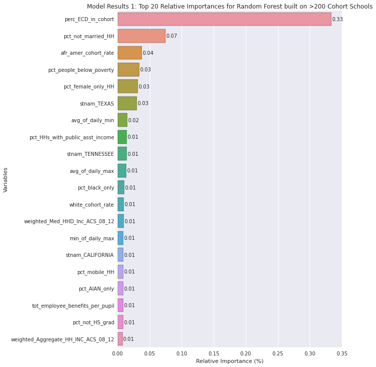

```python
print "Out-of-bag score (R2) for all variables for >200 cohort size schools:", rf_200p.oob_score_.round(2)
print

#make graph
importances_200p = pd.DataFrame(dict(Features=all_vars, Importances=rf_200p.feature_importances_)).sort_values(by = "Importances", ascending = False)

f, ax = plt.subplots(figsize=(8,12))
sb.barplot(x = "Importances", y = "Features", data = importances_200p[0:20], orient = "h")

ax.set(ylabel = "Variables", xlabel = "Relative Importance (%)",
       title = "Model Results 1: Top 20 Relative Importances for Random Forest built on >200 Cohort Schools")

rects = ax.patches
labels = [value for value in importances_200p.Importances]

for rect, label in zip(rects, labels):
    x = label + 0.0015
    y = rect.get_y() + .4
    ax.annotate(label.round(2), xy = (x, y), xytext = (x, y), va="center")
```

### Evaluating the model

This model used ~140 variables (including state dummies). The printed text above the graph shows us that the out-of-bag score for this model is 0.68. (The out-of-bag score for random forests is equivalent to the out-of-sample R2). This means that this model with these variables explain 68% of the variance in the dependent variable. Not bad!

The "Model Results 1" graph shows us the the relative importances of the dependent variables. The variables at the top of the list are the most important, and they decrease in importance going down the list. The household stability and economic security variables seem to dominate the top of the list. The specific variables are: `perc_ECD_in_cohort`, `pct_not_married_HH`, `pct_people_below_poverty`, and `pct_female_only_HH`.

Aside from these variables, there are also some demographic variables that are important, such as black students in the cohort, or racial distributions in the district. However, these are not particularly actionable variables, so we do not spend too much time examining them.

Surprisingly, after household and demographic variables, weather variables seem to be quite important, particularly the `avg_of_daily_min` and `avg_of_daily_max` variables.

We also see the school spending variables make it into the list after the household, demographic, and weather variables. However, there are a few of the spending variables that are grouped together, so it's hard to figure out which one is most important. Thus, in the next section we build a model with spending variables only and see which one is most important.

And lastly, we find that the food access vars are no where near the top of the list. This doesn't mean that they are not important, but rather that they are not as *relatively* important as the other variables in predicting high school graduation rates.

### Which spending variables?

Our next step will be to come up with a simplified list of actionable variables and see how much variance they can explain in the data. But first, we need to figure out which spending variables are most important. The following code takes a crack at that.

```python
# RF for schools with >200 cohort size with just school spending vars
rf_200p_spending = RandomForestRegressor(n_estimators = 300, random_state = 1, oob_score=True)
X, y = create_clean_inputs(school_spending_vars, "clean_grad_rate", grad_rates_greater_than_200_cohort)
rf_200p_spending.fit(X, y)
```

```
RandomForestRegressor(bootstrap=True, compute_importances=None,
           criterion='mse', max_depth=None, max_features='auto',
           max_leaf_nodes=None, min_density=None, min_samples_leaf=1,
           min_samples_split=2, n_estimators=300, n_jobs=1, oob_score=True,
           random_state=1, verbose=0)
```

```
Out-of-bag score (R2) for school spending variables: 0.222974132621
```

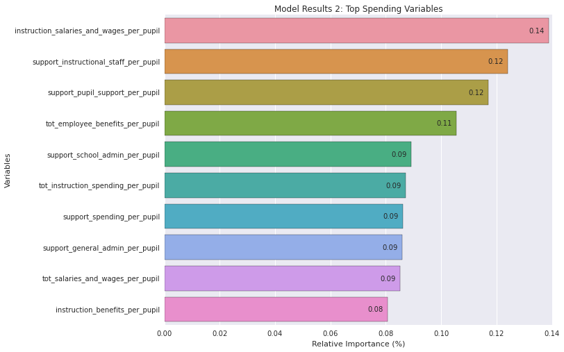

```python
print "Out-of-bag score (R2) for school spending variables:", rf_200p_spending.oob_score_
importances_200p_spending = pd.DataFrame(dict(Features=school_spending_vars, Importances=rf_200p_spending.feature_importances_)).sort_values(by = "Importances", ascending = False)

print
#make graph

f, ax = plt.subplots(figsize=(10, 8))
sb.barplot(x = "Importances", y = "Features", data = importances_200p_spending, orient = "h")

ax.set(ylabel = "Variables", xlabel = "Relative Importance (%)",
       title = "Model Results 2: Top Spending Variables")

rects = ax.patches
labels = [value for value in importances_200p_spending.Importances]

for rect, label in zip(rects, labels):
    x = label - 0.007
    y = rect.get_y() + .4
    ax.annotate(label.round(2), xy = (x, y), xytext = (x, y), va="center")
```

This graph shows us that instructional spending on salaries and wages (`instruction_salaries_and_wages_per_pupil`) is the most important spending variable. We decide to use only this spending variable in the simplified list.

### The simplified variables

After evaluating our model, seeing which features are most important, whittling down the spending variables to just one variable, and narrowing our search to the most actionable variables, we decided to use the following variables in our simplified list:

- Percent economically disadvantaged students in the cohort (perc_ECD_in_cohort)
- Percent unmarried households (pct_not_married_HH)
- Percent female only households (pct_female_only_HH)
- Percent of people below the poverty line (pct_people_below_poverty)
- Instructional spending on salaries and wages per pupil (instruction_salaries_and_wages_per_pupil)
- Average of the daily maximum temperature (avg_of_daily_max)
- Average of the daily minimum temperature (avg_of_daily_min)

The follow code builds a model using only these variables.

```python
simplified_vars = ["perc_ECD_in_cohort", "pct_not_married_HH", "pct_female_only_HH",
                   "pct_people_below_poverty", "instruction_salaries_and_wages_per_pupil",
                   "avg_of_daily_min", "avg_of_daily_max"]
```

```python
rf_simplified = RandomForestRegressor(n_estimators = 300, random_state = 1, oob_score=True)
X, y = create_clean_inputs(simplified_vars, "clean_grad_rate", grad_rates_greater_than_200_cohort)
rf_simplified.fit(X, y)
```

```
RandomForestRegressor(bootstrap=True, compute_importances=None,
           criterion='mse', max_depth=None, max_features='auto',
           max_leaf_nodes=None, min_density=None, min_samples_leaf=1,
           min_samples_split=2, n_estimators=300, n_jobs=1, oob_score=True,
           random_state=1, verbose=0)
```

```
Out-of-bag score (R2) for simplified list of variables: 0.603
```

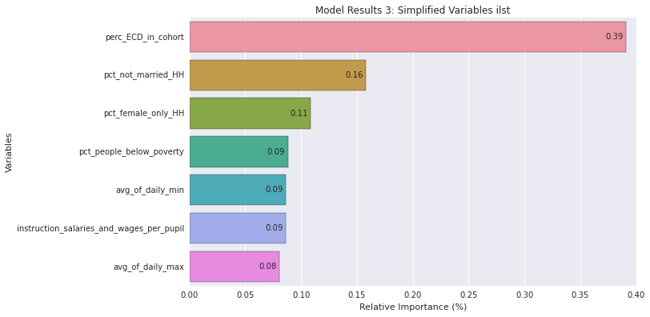

```python
print "Out-of-bag score (R2) for simplified list of variables:", rf_simplified.oob_score_.round(3)
print

importances_200p_simplified = pd.DataFrame(dict(Features=simplified_vars, Importances=rf_simplified.feature_importances_)).sort_values(by = "Importances", ascending = False)

#make graph
f, ax = plt.subplots(figsize=(10, 6))
sb.barplot(x = "Importances", y = "Features", data = importances_200p_simplified, orient = "h")

ax.set(ylabel = "Variables", xlabel = "Relative Importance (%)",
       title = "Model Results 3: Simplified Variables ilst")

rects = ax.patches
labels = [value for value in importances_200p_simplified.Importances]

for rect, label in zip(rects, labels):
    x = label - 0.018
    y = rect.get_y() + .4
    ax.annotate(label.round(2), xy = (x, y), xytext = (x, y), va="center")
```

### Evaluating the simplified model

Looking at the text above, we see that the R-squared for these variables is .60, meaning we can explain 60% of the variation in graduation rates with these 7 variables. That's quite astounding if you think about that. Previously, we had ~140 variables and we were explaining 68% of the variation in graduation rates. We kept only 7 of those and we were still able to explain about 60% of the variation.

It's even more interesting when you look at which variables are included. The most important predictor is how many economically disadvantaged students are in the cohort, which makes sense and is something that the organizers included in their baseline model.

The next two most important variables are how many unmarried and female-householder-only households there are in the dataset. These variables are in a similar position compared to the list of most important features in the model with all the variables. While household stability has been [examined as a factor in academic success](http://www.urban.org/research/publication/negative-effects-instability-child-development-research-synthesis), what these analyses show is that, controlling for other factors such as economic security, income, rural vs urban populations, and many other variables, household stability (as operationalized by unmarried and female-householder-only households) are the most important.

Next we have how many people are below the poverty line. Again, this makes intuitive sense, but note that it is still not as important as the household stability variables.

Surprisingly, we found that weather variables were important in both the model with all the variables and the one with the simplified variables list.

### Generalizing the results

We want to make sure that these results, limited to schools with >200 cohort sizes, can be generalized to the other schools in the dataset. To do this, we build a model looking at schools with >60 cohort sizes and see if the most important features are similar to what we found in the model with only schools with >200 cohort sizes.

```python
rf_60p = RandomForestRegressor(n_estimators = 300, random_state = 1, oob_score=True)
X, y = create_clean_inputs(all_vars, "clean_grad_rate", grad_rates_greater_than_60_cohort)
rf_60p.fit(X, y)
```

```
RandomForestRegressor(bootstrap=True, compute_importances=None,
           criterion='mse', max_depth=None, max_features='auto',
           max_leaf_nodes=None, min_density=None, min_samples_leaf=1,
           min_samples_split=2, n_estimators=300, n_jobs=1, oob_score=True,
           random_state=1, verbose=0)
```

```
Out-of-bag score (R2) for all variables for >60 cohort size schools: 0.61
```

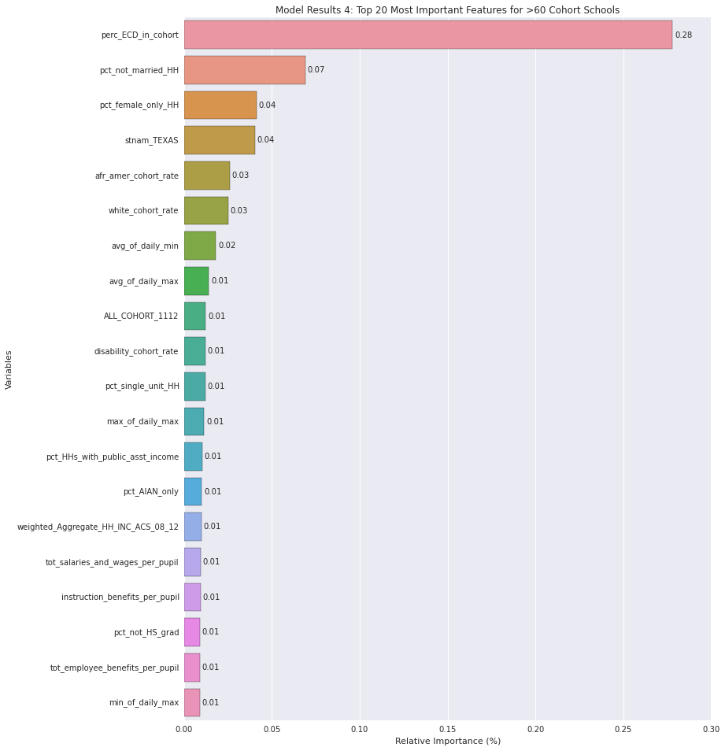

```python
print "Out-of-bag score (R2) for all variables for >60 cohort size schools:", rf_60p.oob_score_.round(2)
print

importances_60p = pd.DataFrame(dict(features=all_vars, importances=rf_60p.feature_importances_)).sort_values(by = "importances", ascending = False)


f, ax = plt.subplots(figsize=(12, 16))
sb.barplot(x = "importances", y = "features", data = importances_60p[0:20], orient = "h")

ax.set(ylabel = "Variables", xlabel = "Relative Importance (%)",
       title = "Model Results 4: Top 20 Most Important Features for >60 Cohort Schools")

rects = ax.patches
labels = [value for value in importances_60p.importances]

for rect, label in zip(rects, labels):
    x = label + 0.0015
    y = rect.get_y() + .4
    ax.annotate(label.round(2), xy = (x, y), xytext = (x, y), va="center")
```

As we can see, the important features list for this model generally mirrors the important features list for the previous model. This provides justification for generalizing the original model's results to schools with less than 200 students in the cohort.

(Note that the variable for how many students are in a cohort (`ALL_COHORT_1112`) has creeped its way up the list. This is because we are now looking at schools with graduation rates calculated as median values of ranges. These graduation rates are only for schools with less less than or equal to 200 students in the cohort. Therefore, the number of students in a cohort becomes a strong signal for what the graduation rate is. If we know that the cohort size is less than or equal to 200 students, then we can infer that the value will be a *median* value in a range of 4 or 5 numbers. The model is using similar logic, which is why the `ALL_COHORT_1112` variable has become more important now that we are looking at schools with calculated median graduation rates).

### Direction of the effects

One downside of random forests is that while they show relative importances, they don't show the general direction of the effect of a variables. In order to get a sense of the general effect, we fit a linear regression model on the data.

It's important to keep in mind that while linear regression can help us estimate the general direction of an effect, it is probably not a good *predictive* model to use for this data. The reason is that linear regression makes some big assumptions about the data, specifically that: a) the relationships are linear and b) all the variables are independent. This means that linear regression won't recognize nonlinearities or interactions between variables, which are probably prevalent in data this big and complex.

On the other hand, random forest *does* allow for nonlinear relationships and interactions between variables. For this reason, we chose it as our primary *predictive* model.

So without further ado, let's check out the linear regression.

```python
import statsmodels.formula.api as sm
from statsmodels.tools.tools import add_constant

X, y = create_clean_inputs(simplified_vars, "clean_grad_rate", grad_rates_greater_than_200_cohort)
sm_model = sm.OLS(y, add_constant(X), missing = "drop").fit()
sm_model.summary()
```

OLS Regression Results

| Dep. Variable: | clean_grad_rate | R-squared: | 0.494 |
| --- | --- | --- | --- |
| Model: | OLS | Adj. R-squared: | 0.493 |
| Method: | Least Squares | F-statistic: | 476.2 |
| Date: | Tue, 17 Nov 2015 | Prob (F-statistic): | 0.00 |
| Time: | 11:56:07 | Log-Likelihood: | -11664. |
| No. Observations: | 3422 | AIC: | 2.334e+04 |
| Df Residuals: | 3414 | BIC: | 2.339e+04 |
| Df Model: | 7 |  |  |

|  | coef | std err | t | P>\|t\| | [95.0% Conf. Int.] |
| --- | --- | --- | --- | --- | --- |
| const | 94.4327 | 1.465 | 64.472 | 0.000 | 91.561 97.304 |
| perc_ECD_in_cohort | -0.1180 | 0.010 | -12.079 | 0.000 | -0.137 -0.099 |
| pct_not_married_HH | -0.2157 | 0.020 | -10.929 | 0.000 | -0.254 -0.177 |
| pct_female_only_HH | -0.5577 | 0.048 | -11.537 | 0.000 | -0.652 -0.463 |
| pct_people_below_poverty | -0.1812 | 0.030 | -6.003 | 0.000 | -0.240 -0.122 |
| instruction_salaries_and_wages_per_pupil | 0.0003 | 9.39e-05 | 3.264 | 0.001 | 0.000 0.000 |
| avg_of_daily_min | 0.0443 | 0.055 | 0.810 | 0.418 | -0.063 0.151 |
| avg_of_daily_max | 0.1653 | 0.042 | 3.934 | 0.000 | 0.083 0.248 |

| Omnibus: | 909.416 | Durbin-Watson: | 1.329 |
| --- | --- | --- | --- |
| Prob(Omnibus): | 0.000 | Jarque-Bera (JB): | 4894.680 |
| Skew: | -1.158 | Prob(JB): | 0.00 |
| Kurtosis: | 8.382 | Cond. No. | 5.63e+04 |

Of the three tables above, take a look at the the middle table. The middle table shows each variable and its coeffecient (see the `coef` column). The coeffecient tells us the general direction of the effect of the variable. So for example, the percent of economically disadvantaged students in the cohort (`perc_ECD_in_cohort`) has a negative coeffecient. This means that as this variable increases in a school district, graduation rates tend to *decrease*.

The following list summarizes the directions:

- Percent economically disadvantaged students in the cohort (`perc_ECD_in_cohort`): negative effect
- Percent unmarried households (`pct_not_married_HH`): negative effect
- Percent female only households (`pct_female_only_HH`): negateive effect
- Percent of people below the poverty line (`pct_people_below_poverty`): negative effect
- Instructional spending on salaries and wages per pupil (`instruction_salaries_and_wages_per_pupil`): positive effect
- Average of the daily maximum temperature (`avg_of_daily_max`): positive effect
- Average of the daily minimum temperature (`avg_of_daily_min`): positive effect

Note that our temperature variables (`avg_of_daily_max` and `avg_of_daily_min`) both have a positive effect. This implies that as the temperature gets *warmer*, graduation rates tend to increase. This means that colder areas are have generally lower graduation rates.

This makes intuitive sense because there is no school held in the summer, but there is school held during winter. So hotter areas, where winters are mild and summers extreme, fare better because school is held during the mild months and not the extreme months. On the other hand, in colder areas, summers are mild and winters are more extreme, so they fare worse because school is held during the extreme months but not the mild months.

### Direction of the effects for spending variables

We also were curious about the directions of the rest of the spending variables. We wanted to see how other types of spending compared to instruction spending on salaries and wages. The linear regression below includes just the spending variables to get a sense of their effect.

```python
import statsmodels.formula.api as sm
from statsmodels.tools.tools import add_constant


simplified_spending_vars = ["instruction_salaries_and_wages_per_pupil",
                  "instruction_benefits_per_pupil",
                  "support_pupil_support_per_pupil",
                  "support_instructional_staff_per_pupil",
                  "support_general_admin_per_pupil",
                  "support_school_admin_per_pupil"]

X, y = create_clean_inputs(simplified_spending_vars, "clean_grad_rate", grad_rates_greater_than_200_cohort)
sm_model = sm.OLS(y, add_constant(X), missing = "drop").fit()
sm_model.summary()
```

OLS Regression Results

| Dep. Variable: | clean_grad_rate | R-squared: | 0.113 |
| --- | --- | --- | --- |
| Model: | OLS | Adj. R-squared: | 0.112 |
| Method: | Least Squares | F-statistic: | 73.08 |
| Date: | Tue, 17 Nov 2015 | Prob (F-statistic): | 4.83e-86 |
| Time: | 11:56:07 | Log-Likelihood: | -12694. |
| No. Observations: | 3435 | AIC: | 2.540e+04 |
| Df Residuals: | 3428 | BIC: | 2.545e+04 |
| Df Model: | 6 |  |  |

|  | coef | std err | t | P>\|t\| | [95.0% Conf. Int.] |
| --- | --- | --- | --- | --- | --- |
| const | 80.5806 | 0.568 | 141.840 | 0.000 | 79.467 81.694 |
| instruction_salaries_and_wages_per_pupil | 0.0042 | 0.000 | 18.684 | 0.000 | 0.004 0.005 |
| instruction_benefits_per_pupil | -0.0040 | 0.000 | -9.972 | 0.000 | -0.005 -0.003 |
| support_pupil_support_per_pupil | -0.0020 | 0.001 | -3.785 | 0.000 | -0.003 -0.001 |
| support_instructional_staff_per_pupil | -0.0079 | 0.001 | -11.462 | 0.000 | -0.009 -0.007 |
| support_general_admin_per_pupil | -0.0018 | 0.001 | -1.440 | 0.150 | -0.004 0.001 |
| support_school_admin_per_pupil | -0.0054 | 0.001 | -4.819 | 0.000 | -0.008 -0.003 |

| Omnibus: | 736.059 | Durbin-Watson: | 1.489 |
| --- | --- | --- | --- |
| Prob(Omnibus): | 0.000 | Jarque-Bera (JB): | 1777.476 |
| Skew: | -1.180 | Prob(JB): | 0.00 |
| Kurtosis: | 5.618 | Cond. No. | 1.80e+04 |

This chart shows us that only instructional spending on salaries and wages tends to increase graduation rates. The other types of spending tend to *decrease* graduation rates. This includes adminstrative spending, but more suprisingly, it also includes support spending for students (which includes social services).

### What would happen if we were able to change these variables nationwide?

This part is cool. We wanted to see what would happen if we could decrease the percent of people under the poverty line by, let's say, 25%. How would the graduation rate change?

First, what is the national graduation rate? The code below shows us.

```python
graduates = grad_rates_greater_than_200_cohort.clean_grad_rate * grad_rates_greater_than_200_cohort.ALL_COHORT_1112
all_students = grad_rates_greater_than_200_cohort.ALL_COHORT_1112.sum()

national_graduation_rate = sum(graduates) / all_students
national_graduation_rate
```

```
81.571397808869847
```

For schools with cohorts larger than 200, the national graduation rates is 81.5%.

Back to our original question: how would this graduation rate change if we were able to change a certain variable across the entire nation? To do this, we used our model to make predictions for all of the districts in the dataset, assuming that one of the variables had changed between -50% and 50%.

This is a little abstract right now, so first check out the charts below.

```python
daily_max_change_effect = pd.read_csv("daily_max_change_effect.csv")
daily_min_change_effect = pd.read_csv("daily_min_change_effect.csv")
ecd_students_change_effect = pd.read_csv("ecd_students_change_effect.csv")
female_only_householder_change_effect = pd.read_csv("female_only_householder_change_effect.csv")
instruction_spending_change_effect = pd.read_csv("instruction_spending_change_effect.csv")
ppl_below_poverty_line_change_effect = pd.read_csv("ppl_below_poverty_line_change_effect.csv")
unmarried_households_change_effect = pd.read_csv("unmarried_households_change_effect.csv")
```

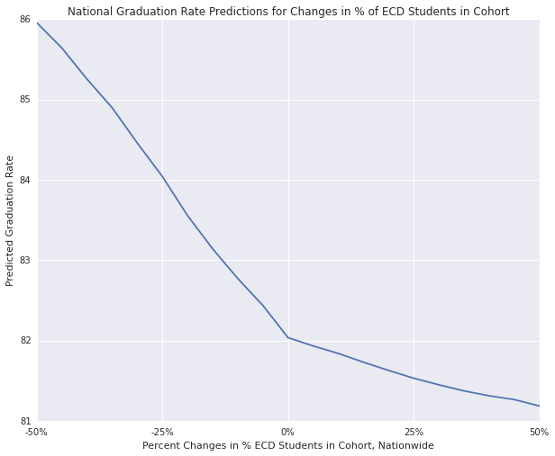

```python
sb.set_style("darkgrid")
plot = ecd_students_change_effect.plot(x = "Percent Changes in Feature", y = "Predicted National Graduation Rate",
                                   legend = None)
plot.set(xlabel="Percent Changes in % ECD Students in Cohort, Nationwide",
        ylabel = "Predicted Graduation Rate", title = "National Graduation Rate Predictions for Changes in % of ECD Students in Cohort")
```

What the graph above shows is our model's predictions for the national graduation rate if we changed how many economically-disadvantaged students there are in each district across the nation by a certain percentage.

So in this case, if we reduced the percentage of ECD students in the cohort in every district across the nation by 50%, we would increase the national graduation rate to 86%. Similarly, if we increased the percent of ECD students across the nation by 50%, graduation rates would drop to 81%. This also helps to confirm the direction of the effect that we picked up on earlier.

We do this with each of the seven variables in our simplified list of variables below.

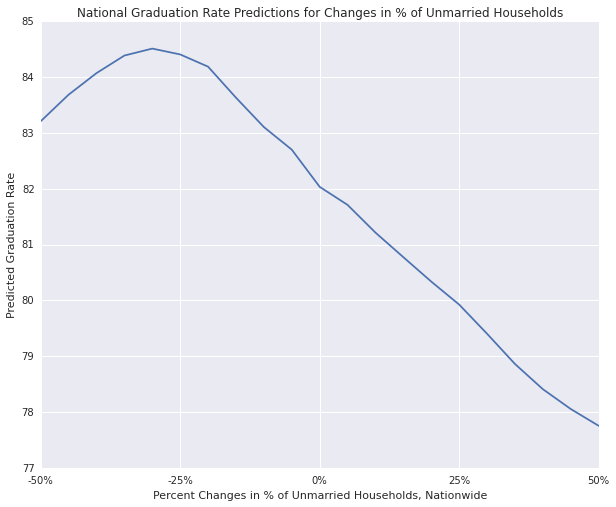

```python
sb.set_style("darkgrid")
plot = unmarried_households_change_effect.plot(x = "Percent Changes in Feature", y = "Predicted National Graduation Rate",
                                   legend = None)
plot.set(xlabel="Percent Changes in % of Unmarried Households, Nationwide",
        ylabel = "Predicted Graduation Rate", title = "National Graduation Rate Predictions for Changes in % of Unmarried Households")
```

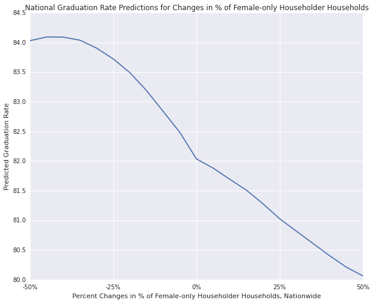

```python
sb.set_style("darkgrid")
plot = female_only_householder_change_effect.plot(x = "Percent Changes in Feature", y = "Predicted National Graduation Rate",
                                   legend = None)
plot.set(xlabel="Percent Changes in % of Female-only Householder Households, Nationwide",
        ylabel = "Predicted Graduation Rate", title = "National Graduation Rate Predictions for Changes in % of Female-only Householder Households")
```

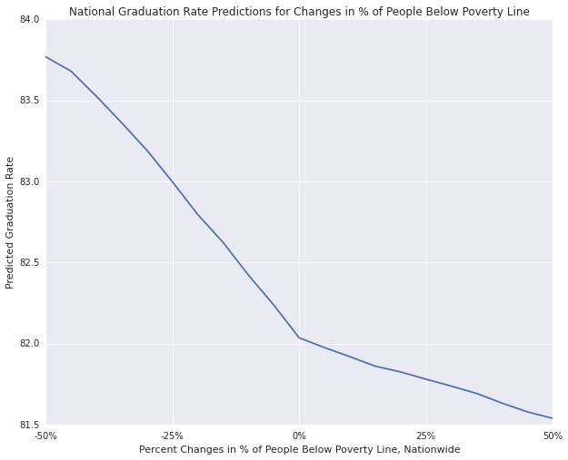

```python
sb.set_style("darkgrid")
plot = ppl_below_poverty_line_change_effect.plot(x = "Percent Changes in Feature", y = "Predicted National Graduation Rate",
                                   legend = None)
plot.set(xlabel="Percent Changes in % of People Below Poverty Line, Nationwide",
        ylabel = "Predicted Graduation Rate", title = "National Graduation Rate Predictions for Changes in % of People Below Poverty Line")
```

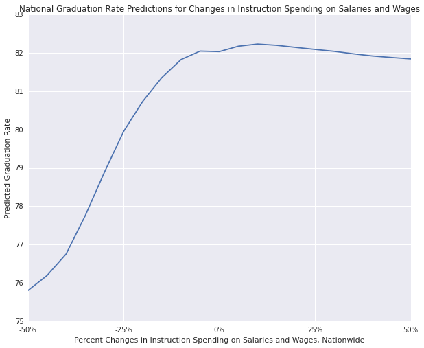

```python
sb.set_style("darkgrid")
plot = instruction_spending_change_effect.plot(x = "Percent Changes in Feature", y = "Predicted National Graduation Rate",
                                   legend = None)
plot.set(xlabel="Percent Changes in Instruction Spending on Salaries and Wages, Nationwide",
        ylabel = "Predicted Graduation Rate", title = "National Graduation Rate Predictions for Changes in Instruction Spending on Salaries and Wages")
```

This graph is very interesting. What it shows is that if we decreased instructional spending on salaries and wages, the graduation rate will decrease. But if we increased this type of spending, the graduation rates would *not* increase, but rather stay about the same. This suggests that spending more money won't improve graduation rates.

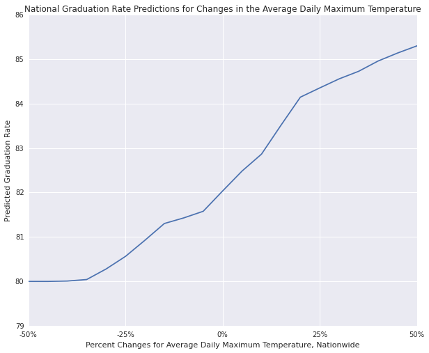

```python
import matplotlib.pyplot as plt
import numpy as np
import seaborn as sb

sb.set_style("darkgrid")
plot = daily_max_change_effect.plot(x = "Percent Changes in Feature", y = "Predicted National Graduation Rate",
                                   legend = None)
plot.set(xlabel="Percent Changes for Average Daily Maximum Temperature, Nationwide",
        ylabel = "Predicted Graduation Rate", title = "National Graduation Rate Predictions for Changes in the Average Daily Maximum Temperature")
```

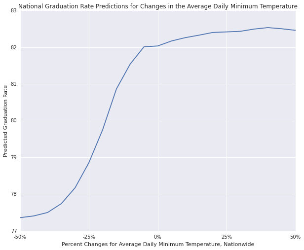

```python
import matplotlib.pyplot as plt
import numpy as np
import seaborn as sb

sb.set_style("darkgrid")
plot = daily_min_change_effect.plot(x = "Percent Changes in Feature", y = "Predicted National Graduation Rate",
                                   legend = None)
plot.set(xlabel="Percent Changes for Average Daily Minimum Temperature, Nationwide",
        ylabel = "Predicted Graduation Rate", title = "National Graduation Rate Predictions for Changes in the Average Daily Minimum Temperature")
```

These temperature charts are also interesting. They corroborate the effect that we found in the linear regression: as temperature increases, graduation rates tend to improve. This provides additional evidence that high school graduation rates are lower in colder areas compared to hotter areas.

### Summary of results

Let's go back to our hypotheses and see which ones held out in the data

1) **Household hypotheses**

*Hypothesis 1*: Students that live in more educated households will be more likely to graduate from high school.

*Variables*:

- Percent of people over 25 years old that graduated high school
- Percent of people over 25 years old that graduated college

*Results*: We found that these variables were not important predictors of high school graduation rates.

*Hypothesis 2*: Students that live in more stable households will be more likely to graduate from high school.

*Variables*:

- Percent of households with married couple
- Percent of households with female only householders (no husband)
- Percent of households where the householder moved in during the past year
- Percent of people who had a different house 1 year ago

*Results*: We found the first two variables, married couple and female-only households, were strong predictors of graduation rates. However, the third and fourth variables, the ones that relate to mobility, were not strong predictors.

This implies that when we discuss househould stability, which is a broad qualitative assessment, we need to be careful of delineating the precise mechanisms that we think are in play. In this case, it seems that temporary disruption in a student's or family's life, such as switching households, did not affect graduation rates very much. However, more chronic instability such as unmarried couple households or female-only householder households do affect graduation rates.

(Note that we are using unmarried couple and female-only householder households as *indicators* of household stability. There are probably many stable households run by unmarried couples or females only, but they are less likely to be stable. This implies that our objective should be to implement policies and programs that improve the stability of traditionally unstable households.)

*Hypothesis 3*: Students that live in economically secure households will be more likely to graduate from high school.

*Variables*:

- Percent of people under the poverty line
- Median household income

*Results*: We found that the percent of people living under the poverty line was a much stronger predictor than median household income. This implies that it's not necessary to raise incomes for everyone, but just for the neediest families. This helps to target policy in the right area: focus people on who need it the most, not necessarily all low-income families.

2) **School hypotheses**

*Hypothesis 4*: Schools that spend more money on instruction tend to have better graduation rates.

*Variables that we used*:

- Total Instructional Spending, per pupil ($)
- Total Instructional Spending on Salaries and Wages, per pupil ($)
- Total Instructional Spending on Benefits, per pupil ($)
- Total Support Spending, per pupil ($)
- Total Support Spending on Pupil Support, per pupil ($)
- Total Support Spending on Instructional Staff Support, per pupil ($)
- Total Support Spending on General Administration, per pupil ($)
- Total Support Spending on School Administration, per pupil ($)

*Results*: in our data analysis, we found that money spent on salaries and wages for instruction was the only type of spending that tended to increase graduation rates. The other types tended to decrease them. This provides support for our hypothesis that schools that allocate resources to instruction tend to perform better than, say, allocating resources to administration or even student support.

However, we also found that there are diminishing returns to school spending, which we saw in the graph that predicts graduation rates assuming that we were to ramp up school spending.

3) **Neighborhood hypotheses**

*Hypothesis 5*: Students that live in districts with greater food access are healthier, and thus perform better in school, leading to higher graduation rates.

*Variables*:

- Percentage of tracts in a district that have low food access. (The precise definition of this variable be found in the documentation of the dataset that we used below, but generally a low food access tract is where a certain number of people in the tract are 1 mile away from a grocery store in urban areas, or 20 miles away from a grocery store in rural areas.)

*Results*: in our data analysis, we found that low food access is not an important predictor of graduation rates. While there is a big movement to increase food access, which is valuable in its own right, it might not be what's needed in order to improve graduation rates.

4) **Region hypotheses**

*Hypothesis 6*: Schools in extreme temperature areas tend to have lower graduation rates compared to schools in more moderate climates.

*Variables*:

- Average daily maximum temperature during 2011 (degrees Farenheit)
- Average daily minimum temperature during 2011 (degrees Farenheit)

# Part V) Recommendations

### Policy Recommendations

We have built a model and analyzed which variables seem to be the most important for predicting graduation rates. Now what can we recommend based off of these insights?

**1) Household Stability and Economic Security**

We've mentioned this a few times, but we're going to hammer this home again: household stability and economic security are not only important factors, but they are the *most* important factors. That being said, what can be done to improve household stability and economic security?

1) [Community development corporations (CDCs)](https://en.wikipedia.org/wiki/Community_development_corporation) are doing some great work in the community space to strengthen communities from a financial and social perspective.

2) Initiatives like the Low Income Housing Tax and the New Markets Tax Credit have brough vital services to low-income communities. Check out [this article](http://www.whatworksforamerica.org/ideas/the-future-of-community-development/#.VkqW59-rRE4) for more information.

3) Schools can step up and introduce programming that is targeted at students who are experiencing rapid or dramatic changes in their household. The goal would be to give them tools to help them cope, continue to allocate resources towards their education, and build a support network. (It might be the case that if support spending was allocated to programs like this, support spending would positively impact graduation rates.)

4) Schools can also step up by providing support to parents who are part of families going through dramatic transitions. This could involve helping parents build skills to deal with stress, remain nurturing towards their children during the transitions, and find other channels of support if needed.

5) State governments could also look into expanding [conditional cash transfers](http://datatopics.worldbank.org/hnp/files/edstats/COLimp08.pdf) for going to school. This would not only incentivize families to send and keep children in school, but also provide addional income that could increase a household's level of economic security.

**2) School spending**

1) We found that more instrucional spending tended to increase graduation rates, while other types tended to decrease it. Thus, all else being equal, it seems that schools should allocate more money towards instructional spending rather than support spending or administrative spending.

2) However, we also saw that our model predicts that graduation rates would *not* change if we increased spending. This suggests that instead of spending more money, we may want to focus on more qualitative factors, such as improving and updating curriculum, allowing for flexibility in course design, etc. We don't want to throw more money into a process when it won't generate results. But if we can create a better process, more money could translate into better higher graduation rates.

2) Our findings also might point to a deficiency in the *support* programs provided by schools, which suprisingly seemed to have a negative effect on graduation rates. Thus, another action item would be to redesign support programs, or at least figure out which ones work better, and focus attention on them.

**3) Inclement weather**

Not much research has been done to examine the relationship between weather and graduation rates. That being said, here are some ways schools can protect themselves against inclement weather:

1) Colder areas tend to have lower graduation rates than warmer areas. One way to design around this problem is to have alternate school schedules for colder areas. It might be better to have a longer break during winter months and a shorter break during summer months for these schools.

2) Schools in cold areas in particular should look to online education as a way to keep students engaged in classes despite inclement weather.

3) Schools in colder areas should also consider infrastructure upgrades. It might be that schools with more robust walking and school transportation infrastructure have lower absentee rates.

**4) Graduation rate data**

For this analysis, we needed to drop many of our observations because of imprecision in the dependent variable. There might be other ways to get around this obstacle, such as imputing imprecise variables based off of other characteristics in the dataset. However, in order to build better and more accurate predictive models, it would be best to have complete, accurate, and precise data.

We realize that there are privacy concerns with releasing graduation rates, but there are other ways to get around that. For example, we could mask the graduation rates with some sort of encryption code to prevent people from figuring out the district that that graduation rate is attributed to. The point is that there are other ways to alleviate privacy concerns.

### Conclusion and further analyses

This analysis sheds some light on where states, cities, and schools should focus their attention on when trying to improve graduation rates. However, more work can be done to deepend our understanding of which factors are relevant. Some further analyses that would be fruitful are:

a) What kind of household instability matters the most? We used variables such as female-only householder households and umarried households, but those are really only proxies for household instability. Household instability is a qualitiative assessment determined by rapid and dramatic transitions and disruptions in a household. There are probably plenty of unmarried households that are relatively stable. Instead, we might want to look at more specific variables, such as divorces, the amount of time single parents invest in children, frequency of relationship turnover of a single parent, etc.

2) School spending data should get more granular. For example, while the student support spending variable includes spending on social services, it also includes other types of student support that were more adminstrative. It would be good to separate out spending on social services vs. spending on other services that fall under student support expenditures. That way, we can get more accurate estimates of the effects of, say, social services.

Alternatively, it would be good to run randomized controlled trials on specific programs run by schools and evaluate the effectiveness of those in order to understand what we should scale up and what we should cut back.

3) With regard to weather data, we should look at the precise causal mechanism between colder weather and lower graduation rates. Is it because of school cancellations? Or lower attendance rates? Or some other reason? Once we understand the causal mechanism, we can better tailor policy recommendations.

The US aims to reach a 90% graduation rate nationwide by 2020. It's doable, but more work needs to be done. We hope this analysis can help us reach that goal.